# Automate, reproduce, win!

Matt Dray  
14 May 2018

### The problem is the process

It's looooong and error-prone.

1. Receive non-machine-readable data in Excel format
2. Use a pre-prepared Excel template to reformat the data
3. Generate figures, tables and plots
4. Copy and paste to ~100-page Word document
5. Find error/need to alter something
6. Spend ages re-copying and re-pasting all instances
7. Get confused about the current working version
8. Repeat steps 5 to 7 until 4am
9. Eventually document is as ready as it can be

### Minimise the risk

We can reduce human error and go faster.

1. Receive machine-readable data in Excel format
2. Run a pre-prepared *R Markdown* file
3. Make minor tweaks if needed and re-render stress-free
4. Use the saved time to prepare more informative commentary and have a cup of tea

### What's R Markdown?

- Write plain text
- Format it with symbols (`*`, `[]`, `^`, etc)
- Embed R code
- Click a button to render into HTML, Word or PDF

### Formatting

You type

You get

`*italic*`

*italic*

`**bold**`

**bold**

`super^script`

super<sup>script</sup>

`* bullet`

- bullet

`[Link]()`

Link

`![](img/cat.png)`

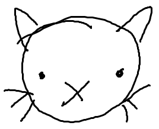

More examples are availabe in [this cheatsheet](https://www.rstudio.com/wp-content/uploads/2015/03/rmarkdown-reference.pdf).

### Code in R Markdown (1/2)

You can write some R code in the middle of a sentence!

For example: write `` `r 1 + 1` `` in a sentence and it will render as '2'.

(Don't worry about the actual code; just know that this is possible.)

### Basic process

1. Open a file with the .Rmd (R Markdown) extension
2. Write your report using R Markdown
3. Embed code that calculates values or produces plots and tables, for example
4. Use the `knitr` package to *knit* the document, rendering your R Markdown into a 'proper' document for sharing
5. File > New File > R Markdown
6. You write a plain text file and format it with symbols
7. You intersperse it with your R code
8. You render the file and it spits out your fully-formed document